# EP02-respuesta-equipo-2

2. Preguntas asignadas al grupo:

   El Comité Olímpico cree que el mejor tiempo medio de los atletas de la zona Centro-Sur antes de ingresar al programa de entrenamiento era inferior a 19,8 segundos. ¿Soportan los datos esta afirmación?

   ¿Sugieren los datos que la mejor marca de los atletas de la zona Sur se reduce en promedio más de 1,9 segundos tras el entrenamiento?

   ¿Es posible afirmar que, en promedio, los atletas de la zona Sur superan a los de la zona Centro-Sur por 2 segundos después del entrenamiento?

   ¿Será cierto que hay menos atletas de la zona Centro-Sur quer edujeron sus mejores marcas en al menos 5,5 segundos que atletas de la zona Centro-Norte que lo hicieron en al menos 3 segundos?
3. Proponer una hipótesis nula y una hipótesis alternativa para cada caso (cada pregunta)

Pregunta 1: El Comité Olímpico cree que el mejor tiempo medio de los atletas de la zona Centro-Sur antes de ingresar al programa de entrenamiento era inferior a 19,8 segundos. ¿Soportan los datos esta afirmación?

$H_0$=el mejor tiempo medio de los atletas de la zona centro-sur antes de ingresar al programa de entrenamiento es mayor o igual a 19,8 segundos.

$H_1$=el mejor tiempo medio de los atletas de la zona centro-sur antes de ingresar al programa de entrenamiento es menor a 19,8 segundos.

Pregunta 2: ¿Sugieren los datos que la mejor marca de los atletas de la zona Sur se reduce en promedio más de 1,9 segundos tras el entrenamiento?

$H_0$=la mejor marca de los atletas de la zona sur aumenta o se mantiene en 1,9 segundos tras el entrenamiento.

$H_1$=la mejor marca de los atletas de la zona sur disminuye más de 1,9 segundos tras el entrenamiento.

Pregunta 3: ¿Es posible afirmar que, en promedio, los atletas de la zona Sur superan a los de la zona Centro-Sur por 2 segundos después del entrenamiento?

$H_0$=en promedio, los atletas de la zona sur igualan o son superados por los de los de la zona centro-sur por 2 segundos.

$H_1$=en promedio, los atletas de la zona sur superan a los de la zona centro-sur por 2 segundos.

Pregunta 4: ¿Será cierto que hay menos atletas de la zona Centro-Sur quer edujeron sus mejores marcas en al menos 5,5 segundos que atletas de la zona Centro-Norte que lo hicieron en al menos 3 segundos?

$H_0$=la proporción de atletas de la zona centro-sur que redujeron al menos 5,5 segundos es mayor o igual a la de la zona centro-norte que redujeron al menos 3 segundos.

$H_1$=la proporción de atletad de la zona centro-sur que redujeron al menos 5,5 segundos es menor a la de la zona centro-norte que redujeron al menos 3 segundos.

4. Escribir código R para verificar que se cumplen las condiciones necesarias para docimar las hipótesis con las pruebas seleccionadas.

Pregunta 1.

```r
# Tamaño de la muestra
length(centro_sur)
```

```
## [1] 27
```

```r
# Normalidad (Shapiro-Wilk)
shapiro.test(centro_sur)
```

```
##
##  Shapiro-Wilk normality test
##
## data:  centro_sur
## W = 0.98354, p-value = 0.932
```

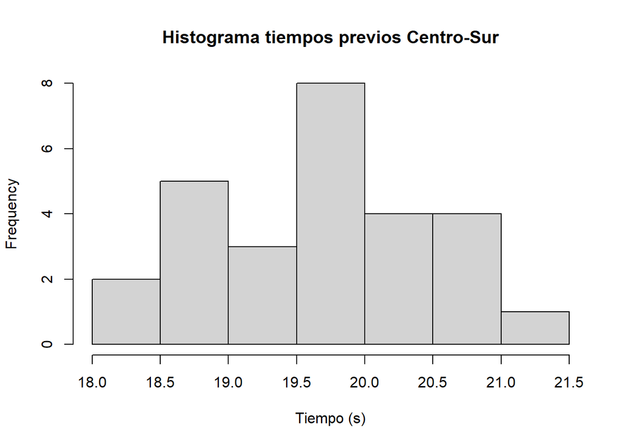

```r
# Gráficos para evaluar normalidad
hist(centro_sur, main="Histograma tiempos previos Centro-Sur", xlab="Tiempo (s)")
```

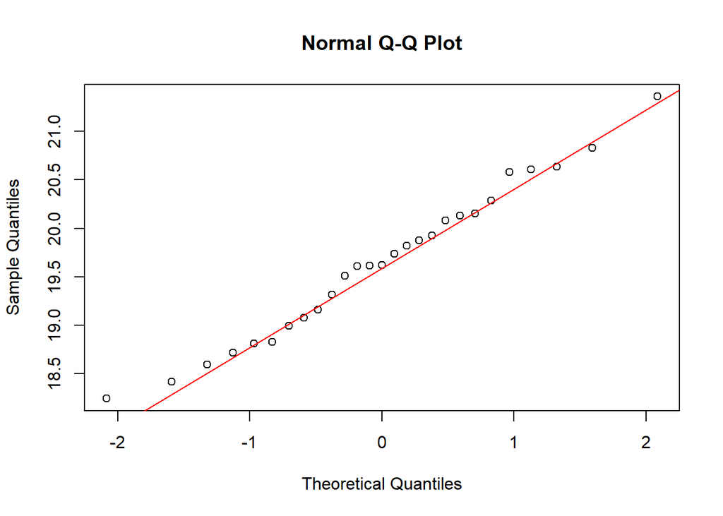

```r
qqnorm(centro_sur)
qqline(centro_sur, col="red")
```

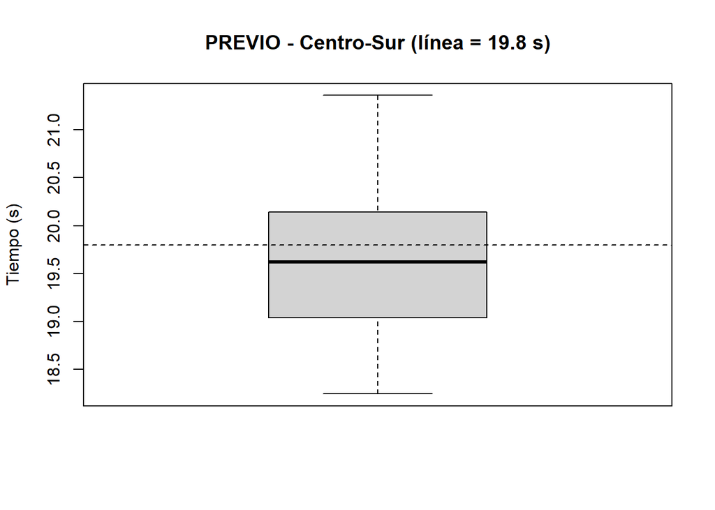

```r
#Boxplot
boxplot(centro_sur, main = "PREVIO - Centro-Sur (línea = 19.8 s)",
        ylab = "Tiempo (s)")
abline(h = 19.8, lty = 2)
```

```r
t.test(centro_sur, mu = 19.8, alternative = "less")
```

```
##
##  One Sample t-test
##
## data:  centro_sur
## t = -0.98585, df = 26, p-value = 0.1666
## alternative hypothesis: true mean is less than 19.8
## 95 percent confidence interval:
##      -Inf 19.90965
## sample estimates:
## mean of x
##  19.64981
```

Se cumplen las condiciones necesarias para usar la prueba t de una muestra. Los tiempos de los atletas son independientes, ya que el rendimiento de uno no afecta al de los demás. La prueba de normalidad de Shapiro–Wilk arrojó un p-valor alto, y los gráficos, como el histograma y el QQ-plot, no muestran desviaciones importantes. Esto indica que los datos se ajustan bastante bien a una distribución normal. Además, la variabilidad que observamos tiene sentido en el contexto de los datos . Por último, el tamaño de la muestra es lo suficientemente grande, por lo que utilizar la prueba t en este caso es apropiado y confiable.

Aunque la media muestral observada (19.65 s) es menor a 19.8 s, la diferencia no es estadísticamente significativa (p = 0.1666 > 0.05). Por lo tanto, no hay evidencia suficiente para sostener la afirmación del Comité Olímpico.

Pregunta 2.

```r
# Filtrar solo los atletas de la zona Sur
sur_mejora <- subset(datos, Zona == "Sur")$Previo - subset(datos, Zona == "Sur")$Posterior

#Tamaño de la muestra
length(sur_mejora)
```

```
## [1] 28
```

```r
#Normalidad (Shapiro-Wilk)
shapiro.test(sur_mejora)
```

```
##
##  Shapiro-Wilk normality test
##
## data:  sur_mejora
## W = 0.9781, p-value = 0.8027
```

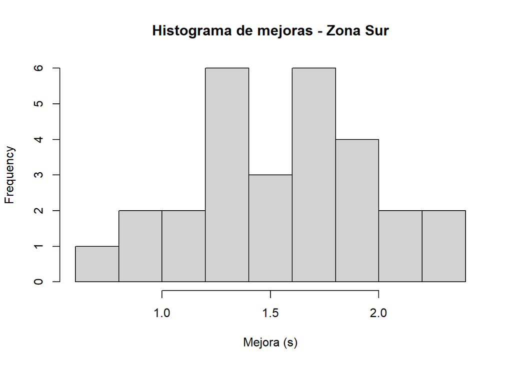

```r
#Gráficos para evaluar normalidad
hist(sur_mejora, main="Histograma de mejoras - Zona Sur", xlab="Mejora (s)")
```

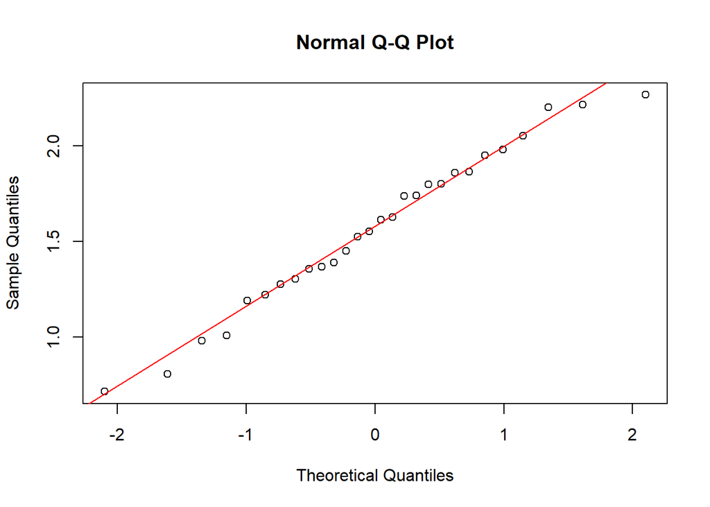

```r
qqnorm(sur_mejora)
qqline(sur_mejora, col="red")
```

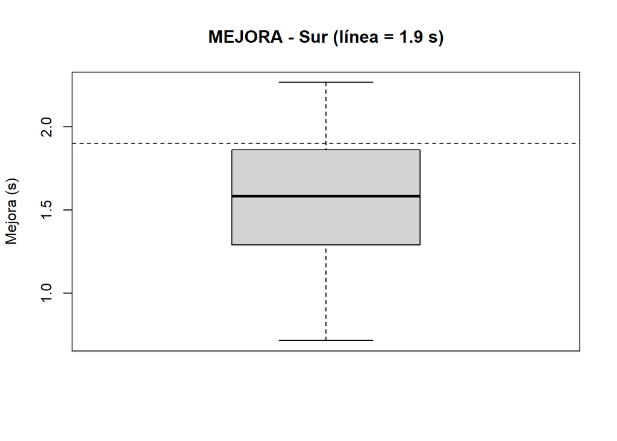

```r
boxplot(sur_mejora, main = "MEJORA - Sur (línea = 1.9 s)",
        ylab = "Mejora (s)")
abline(h = 1.9, lty = 2)
```

```r
t.test(sur_mejora, mu = 1.9, alternative = "greater")
```

```
##
##  One Sample t-test
##
## data:  sur_mejora
## t = -4.2401, df = 27, p-value = 0.9999
## alternative hypothesis: true mean is greater than 1.9
## 95 percent confidence interval:
##  1.431428      Inf
## sample estimates:
## mean of x
##  1.565714
```

Las condiciones para usar la prueba t de una muestra se cumplen, ya que las mejoras en los atletas se consideran independientes entre sí. Además, la prueba de Shapiro–Wilk arrojó un p-valor alto (0.8027), lo que indica que los datos siguen más o menos una distribución normal. La variabilidad en los tiempos tiene sentido en este contexto, y con una muestra de 28 personas, la prueba t es confiable y sólida.

Aunque en promedio los atletas de la zona Sur mejoraron su tiempo en aproximadamente 1.57 segundos, esta mejora es menor a los 1.9 segundos que sugería nuestra hipótesis inicial (nula). El valor del p-valor (0.9999) es mucho más alto que 0.05, lo que significa que no hay evidencia suficiente para rechazar la idea de que no hay cambios significativos. En otras palabras, los datos no respaldan que, después del entrenamiento, la mejora promedio de los atletas en la zona Sur supere los 1.9 segundos.

Pregunta 3.

```r
# Extraer tiempos posteriores por zona
cs_post  <- subset(datos, Zona == "Centro-Sur")$Posterior
sur_post <- subset(datos, Zona == "Sur")$Posterior

# Tamaños muestrales
length(cs_post); length(sur_post)
```

```
## [1] 27
```

```
## [1] 28
```

```r
# Normalidad por grupo (útil si n es pequeño)
shapiro.test(cs_post)
```

```
##
##  Shapiro-Wilk normality test
##
## data:  cs_post
## W = 0.9689, p-value = 0.573
```

```r
shapiro.test(sur_post)
```

```
##
##  Shapiro-Wilk normality test
##
## data:  sur_post
## W = 0.95201, p-value = 0.2225
```

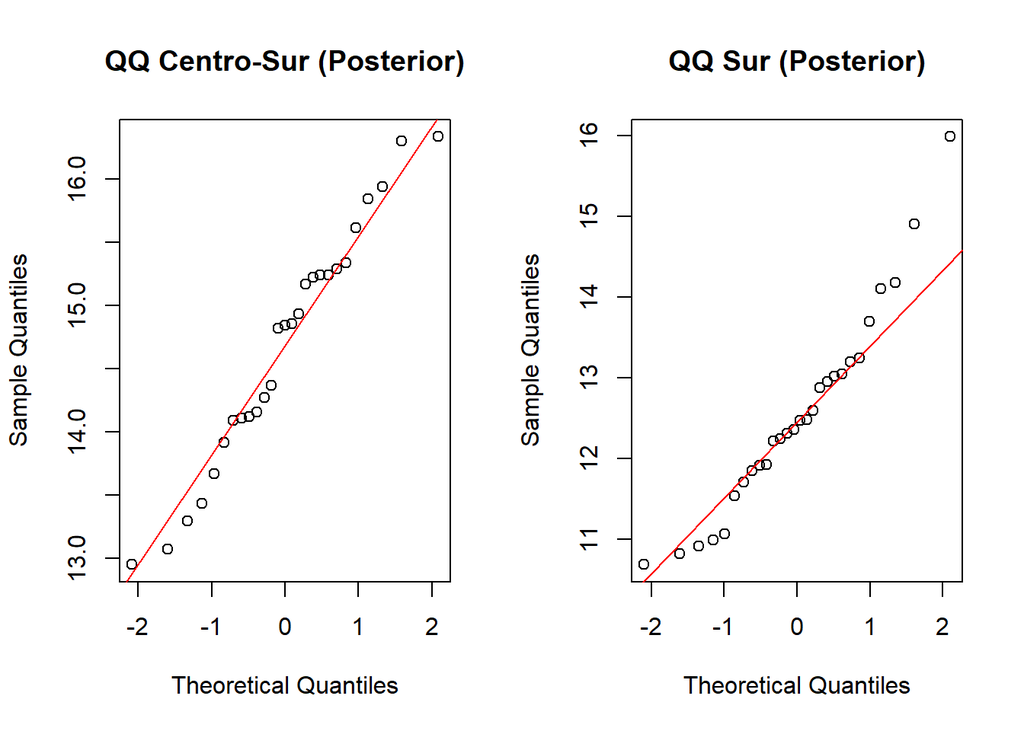

```r
# Gráficos de normalidad
par(mfrow = c(1,2))
qqnorm(cs_post, main = "QQ Centro-Sur (Posterior)"); qqline(cs_post, col="red")
qqnorm(sur_post, main = "QQ Sur (Posterior)");       qqline(sur_post, col="red")
```

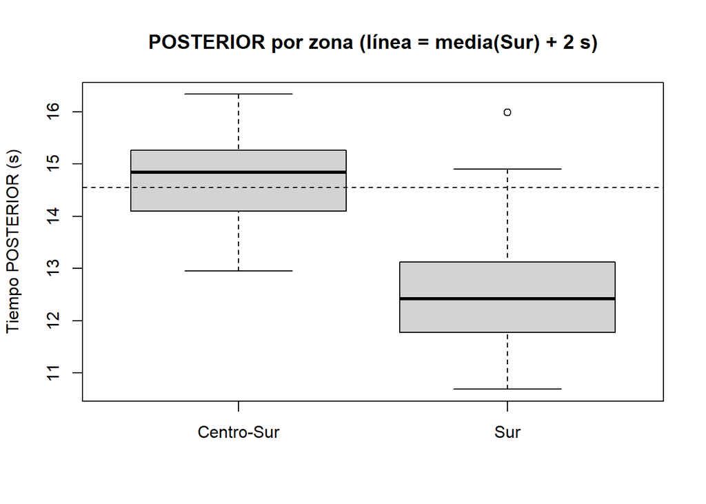

```r
par(mfrow = c(1,1))

m_sur <- mean(sur_post, na.rm = TRUE)

boxplot(list(`Centro-Sur` = cs_post, Sur = sur_post),
        ylab = "Tiempo POSTERIOR (s)",
        main = "POSTERIOR por zona (línea = media(Sur) + 2 s)")
abline(h = m_sur + 2, lty = 2)
```

```r
# Prueba t de Welch: Contrasta mean(CS) - mean(Sur) > 2
t.test(cs_post, sur_post, mu = 2, alternative = "greater")
```

```
##
##  Welch Two Sample t-test
##
## data:  cs_post and sur_post
## t = 0.45366, df = 50.242, p-value = 0.326
## alternative hypothesis: true difference in means is greater than 2
## 95 percent confidence interval:
##  1.633604      Inf
## sample estimates:
## mean of x mean of y
##  14.68333  12.54732
```

Para responder a esta pregunta, se utilizó una prueba t de dos muestras con corrección de Welch. Esto es porque nos permite comparar los tiempos posteriores en la zona Sur y la zona Centro-Sur sin suponer que ambos grupos tengan la misma varianza. Elegimos esta prueba porque los datos cumplen con los requisitos: cada grupo está formado por atletas diferentes (independencia), los tiempos se miden en una escala continua y las pruebas de normalidad de Shapiro–Wilk muestran que las distribuciones no tienen desviaciones importantes. Además, con 27 y 28 atletas en cada grupo, el tamaño de la muestra es suficiente para que los resultados sean confiables desde un punto de vista estadístico.

Aunque en promedio los atletas de la zona Sur tuvieron tiempos más rápidos (12.55 segundos) en comparación con los de la zona Centro-Sur (14.68 segundos), con una diferencia de aproximadamente 2.14 segundos, esta diferencia no es estadísticamente significativa. La prueba t arrojó un p-valor de 0.326, que es mucho mayor que el nivel de confianza de 0.05, por lo que no podemos decir con certeza que la zona Sur sea mejor que la Centro-Sur en 2 segundos después del entrenamiento.

Pregunta 4.

```r
#   Centro-Sur: mejora >= 5.5 s
#   Centro-Norte: mejora >= 3 s
cs_ok <- with(subset(datos, Zona == "Centro-Sur"), Mejora >= 5.5)
cn_ok <- with(subset(datos, Zona == "Centro-Norte"), Mejora >= 3)

# Conteos
x_cs <- sum(cs_ok); n_cs <- length(cs_ok)
x_cn <- sum(cn_ok); n_cn <- length(cn_ok)

cat(sprintf("Centro-Sur: x = %d, n = %d (p̂ = %.3f)\n", x_cs, n_cs, x_cs/n_cs))
```

```
## Centro-Sur: x = 1, n = 27 (p̂ = 0.037)
```

```r
cat(sprintf("Centro-Norte: x = %d, n = %d (p̂ = %.3f)\n\n", x_cn, n_cn, x_cn/n_cn))
```

```
## Centro-Norte: x = 11, n = 26 (p̂ = 0.423)
```

```r
# alternative = "less" porque H1: p_CS < p_CN
prueba_p4 <- prop.test(x = c(x_cs, x_cn), n = c(n_cs, n_cn),
                       alternative = "less", correct = TRUE)
prueba_p4
```

```
##
##  2-sample test for equality of proportions with continuity correction
##
## data:  c(x_cs, x_cn) out of c(n_cs, n_cn)
## X-squared = 9.1734, df = 1, p-value = 0.001228
## alternative hypothesis: less
## 95 percent confidence interval:
##  -1.0000000 -0.1780762
## sample estimates:
##     prop 1     prop 2
## 0.03703704 0.42307692
```

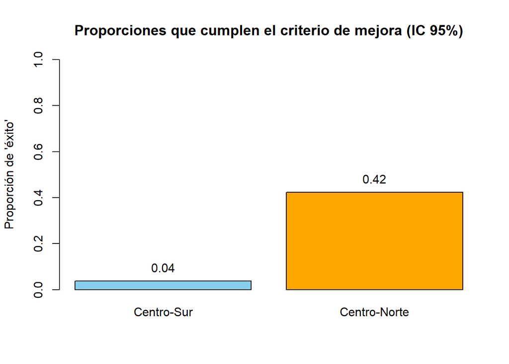

```r
#Gráfico de proporciones con IC 95% (por zona)
ci_cs <- prop.test(x_cs, n_cs, conf.level = 0.95, correct = FALSE)$conf.int
ci_cn <- prop.test(x_cn, n_cn, conf.level = 0.95, correct = FALSE)$conf.int

props <- c(x_cs/n_cs, x_cn/n_cn)

bp <- barplot(props, names.arg = c("Centro-Sur", "Centro-Norte"),
              ylim = c(0, 1), ylab = "Proporción de 'éxito'",
              main = "Proporciones que cumplen el criterio de mejora (IC 95%)",
              col = c("skyblue", "orange"))


# Etiquetas con p-hat
text(x = bp, y = props + 0.06, labels = sprintf("%.2f", props), xpd = TRUE)
```

Para responder esta pregunta, se utilizó una prueba de diferencia de proporciones prop.test. Esta prueba es adecuada porque nos permite comparar fracciones de éxito entre dos grupos independientes: atletas de la zona Centro-Sur que redujeron al menos 5,5 segundos y atletas de la zona Centro-Norte que redujeron al menos 3 segundos. Las condiciones se cumplen porque los datos son independientes, la variable de interés es exitosa o no exitosa y el tamaño muestral, es suficiente para aplicar una aproximación basada en chi-cuadrado.

Los resultados muestran que solo 1 de 27 atletas de la zona Centro-Sur (≈3,7%) alcanzó la mejora definida, en comparación a 11 de 26 en la zona Centro-Norte (≈42,3%). La prueba arrojó un p-valor de 0.0012, mucho menor que el nivel de significancia de 0.05, por lo que rechazamos la hipótesis nula y concluimos que la proporción de atletas de la zona Centro-Sur que lograron la mejora es significativamente menor que la de la zona Centro-Norte.